# pro1

2026-03-06

# 1- Introduction

### Project Background

This report investigates the nutritional status and growth of a sample of 113 infants born at the Queen Mother’s Hospital, Glasgow. The study tracks physical development from 1 month to 24 months of age, examining how early weight and environmental factors like the introduction of solid foods relate to later physical outcomes. ### Questions of Interest Guessing Weight: Can we accurately guess a baby’s weight at 24 months if we only know their weight at 1 month?

Boys vs. Girls: Do boy babies and girl babies gain a different amount of weight on average during their first two years?

# 2-Exploratory Data Analysis

### Exploratory Tables

Summary Statistics by Sex

| Sex | Count | Mean_Wt1 | SD_Wt1 | Mean_Wt24 | SD_Wt24 | Mean_Solids |
| --- | --- | --- | --- | --- | --- | --- |
| Female | 49 | 4.111837 | 0.5535329 | 11.93571 | 1.590992 | 11.42857 |
| Male | 64 | 4.509375 | 0.5152773 | 13.11797 | 1.354076 | 11.50000 |

Comments on Table: Weight Advantage: Male babies start heavier at 1 month (Avg 4.51kg vs 4.11kg) and maintain a higher average weight at 24 months.

Solids Consistency: The average age for starting solid foods is nearly identical for both sexes (approx. 11.5 months), suggesting that feeding choices in this sample were not influenced by the baby’s sex. ### Exploratory Plots Visualising the data helps us check if a linear model is appropriate and if there are any outliers.

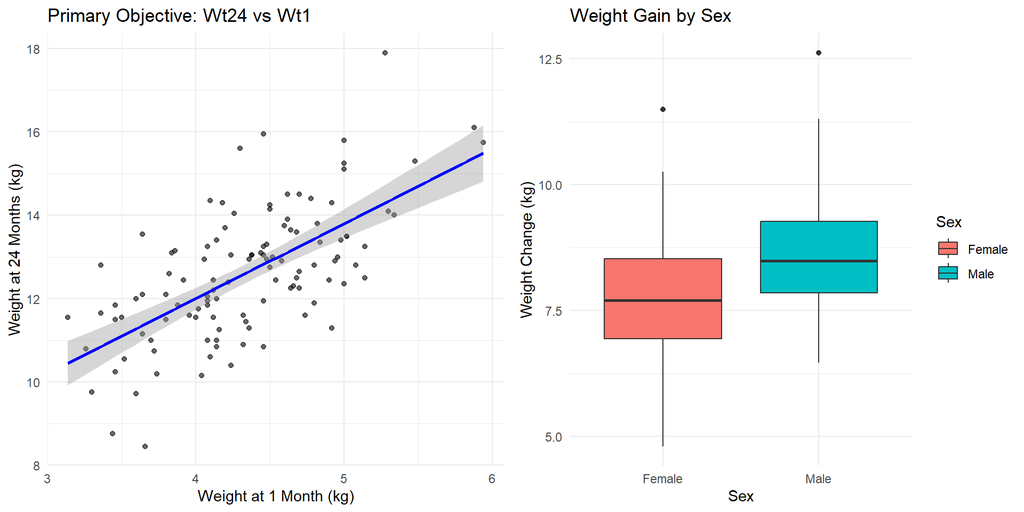

### Description of Methods to be Used

A. Simple Linear Regression (For Question 1) We will use this to model the direct relationship between $Wt1$ and $Wt24$. We look at the $R^2$ value to determine how much of the weight is told by their weight as a 1-month-old.

C. Two-Sample T-Test (For Question 3) To compare the growth difference ($Wt24 - Wt1$) between boys and girls, we use a T-test. This method is used to determine if the difference in the means of two groups is statistically significant.

# 3- Statistical Modelling and Results

###Predicting Weight at 24 Months To determine if weight at 1 month ($Wt1$) is a reliable predictor for weight at 24 months ($Wt24$), a Simple Linear Regression model was fitted.

$$Wt24_i=\beta_{0} +\beta_{1}Wt1_i+\epsilon_i where \space \epsilon_i
\space ∼ N(0,σ^2)$$

$Wt24_i$:Weight at 24 months (kg)for the $i$th baby.

$Wt1_i$ : Weight at 1 months(kg)for the $i$th baby.

```
##
## Call:
## lm(formula = Wt24 ~ Wt1, data = data)
##
## Residuals:
##     Min      1Q  Median      3Q     Max
## -2.9294 -0.7976 -0.0937  0.7234  3.6010
##
## Coefficients:
##             Estimate Std. Error t value Pr(>|t|)
## (Intercept)   4.8159     0.8780   5.485 2.63e-07 ***
## Wt1           1.7960     0.2008   8.946 9.46e-15 ***
## ---
## Signif. codes:  0 '***' 0.001 '**' 0.01 '*' 0.05 '.' 0.1 ' ' 1
##
## Residual standard error: 1.202 on 111 degrees of freedom
## Multiple R-squared:  0.419,  Adjusted R-squared:  0.4137
## F-statistic: 80.03 on 1 and 111 DF,  p-value: 9.456e-15
```

### Question 3: Does the average weight gain differ between Boys and Girls?

To answer this question, we first calculated the total weight gain for each baby ($Weight\ at\ 24\ months\ minus\ Weight\ at\ 1\ month$). We then used a Two-Sample T-test to compare the average growth of boys and girls.

```
##
##  Welch Two Sample t-test
##
## data:  Wt_Diff by Sex
## t = -3.3234, df = 95.887, p-value = 0.00126
## alternative hypothesis: true difference in means between group Female and group Male is not equal to 0
## 95 percent confidence interval:
##  -1.253409 -0.316023
## sample estimates:
## mean in group Female   mean in group Male
##             7.823878             8.608594
```

Results and Interpretation:

- Average gain for Boys is 8.608
- Average gain for Girls is 7.823
- The p-value is 0.001

The p-value is 0.001, which is much smaller than 0.05. In statistics, this means the result is highly significant.

There is a very strong evidence that weight gain during the first two years of life is not the same for both sexes because the p-value is 0.001<0.05 and we have the 95 CI [-1.2534,-0.3160] does not include zero this mean the mean for boys does not equal the mean of girls.

$u_{male} \neq u_{femal}$

On average,boys in this study gained about 0.79 kg more than girls. This confirms that the sex of a baby is a very important factor when studying how they grow.